# Autoencoder_Assignment

## Group 5 Members

- **2024AC05848** - R Poornima
- **2024AD05277** - Yash Baheti
- **2025AB05135** - Yuvashree K

# Assignment: Representation Learning using Variants of Autoencoders

This notebook covers:

- **Task 1**: Standard PCA vs Randomized PCA with 30 principal components, logistic regression classification, ROC curves, and SNR analysis
- **Task 2**: Single-layer linear autoencoder with tied weights, eigenvector comparison with PCA, and logistic regression
- **Task 3**: Deep convolutional autoencoder, single-layer autoencoder (sigmoid/linear), 3-hidden-layer autoencoder, SNR comparison

## 0. Setup and Data Preparation

```python
import numpy as np
import matplotlib.pyplot as plt
import warnings
warnings.filterwarnings('ignore')

# For reproducibility
np.random.seed(42)

from sklearn.decomposition import PCA
from sklearn.linear_model import LogisticRegression
from sklearn.metrics import roc_curve, auc, roc_auc_score
from sklearn.preprocessing import label_binarize
from sklearn.model_selection import train_test_split
from skimage.color import rgb2gray
from skimage.transform import resize

import tensorflow as tf
from tensorflow import keras
from tensorflow.keras import layers, Model, backend as K
from tensorflow.keras.callbacks import EarlyStopping

print(f"TensorFlow version: {tf.__version__}")
print(f"GPU available: {tf.config.list_physical_devices('GPU')}")
```

```
TensorFlow version: 2.19.0
GPU available: []
```

```python
# Load CIFAR-10 and MNIST
(cifar_train_x, cifar_train_y), (cifar_test_x, cifar_test_y) = keras.datasets.cifar10.load_data()
(mnist_train_x, mnist_train_y), (mnist_test_x, mnist_test_y) = keras.datasets.mnist.load_data()

# Merge train/test for our own split
cifar_x = np.concatenate([cifar_train_x, cifar_test_x], axis=0)
cifar_y = np.concatenate([cifar_train_y, cifar_test_y], axis=0).flatten()
mnist_x = np.concatenate([mnist_train_x, mnist_test_x], axis=0)
mnist_y = np.concatenate([mnist_train_y, mnist_test_y], axis=0).flatten()

print(f"CIFAR-10 full: {cifar_x.shape}, labels: {cifar_y.shape}")
print(f"MNIST full: {mnist_x.shape}, labels: {mnist_y.shape}")
```

```
Downloading data from https://www.cs.toronto.edu/~kriz/cifar-10-python.tar.gz
170498071/170498071 ━━━━━━━━━━━━━━━━━━━━ 15s 0us/step
Downloading data from https://storage.googleapis.com/tensorflow/tf-keras-datasets/mnist.npz
11490434/11490434 ━━━━━━━━━━━━━━━━━━━━ 3s 0us/step
CIFAR-10 full: (60000, 32, 32, 3), labels: (60000,)
MNIST full: (70000, 28, 28), labels: (70000,)
```

```python
def preprocess_cifar10(images):
    """Convert CIFAR-10 RGB to grayscale and resize to 28x28"""
    processed = []
    for img in images:
        gray = rgb2gray(img)  # Convert to grayscale (0-1 range)
        gray_resized = resize(gray, (28, 28), anti_aliasing=True)
        processed.append(gray_resized)
    return np.array(processed)

def preprocess_mnist(images):
    """MNIST is already 28x28 grayscale, just ensure float"""
    return images.astype('float32') / 255.0

def normalize_intensity(images, low=50, high=200):
    """Normalize intensity between low and high"""
    img_min = images.min()
    img_max = images.max()
    normalized = (images - img_min) / (img_max - img_min)  # 0 to 1
    normalized = normalized * (high - low) + low  # Scale to [low, high]
    return normalized

print("Preprocessing CIFAR-10...")
cifar_x_proc = preprocess_cifar10(cifar_x)
print(f"CIFAR-10 after grayscale+resize: {cifar_x_proc.shape}, range: [{cifar_x_proc.min():.3f}, {cifar_x_proc.max():.3f}]")

print("Preprocessing MNIST...")
mnist_x_proc = preprocess_mnist(mnist_x)
print(f"MNIST after preprocessing: {mnist_x_proc.shape}, range: [{mnist_x_proc.min():.3f}, {mnist_x_proc.max():.3f}]")

# Normalize intensities to [50, 200]
cifar_x_norm = normalize_intensity(cifar_x_proc, 50, 200)
mnist_x_norm = normalize_intensity(mnist_x_proc, 50, 200)

print(f"\nCIFAR-10 normalized: range [{cifar_x_norm.min():.2f}, {cifar_x_norm.max():.2f}]")
print(f"MNIST normalized: range [{mnist_x_norm.min():.2f}, {mnist_x_norm.max():.2f}]")
```

```
Preprocessing CIFAR-10...
CIFAR-10 after grayscale+resize: (60000, 28, 28), range: [0.000, 1.000]
Preprocessing MNIST...
MNIST after preprocessing: (70000, 28, 28), range: [0.000, 1.000]

CIFAR-10 normalized: range [50.00, 200.00]
MNIST normalized: range [50.00, 200.00]
```

```python
# Split: 70% train, 20% validation, 10% test
def split_data(X, y):
    # First split: 70% train, 30% temp
    X_train, X_temp, y_train, y_temp = train_test_split(
        X, y, test_size=0.30, random_state=42, stratify=y
    )
    # Second split: 20% val, 10% test from temp (2/3 val, 1/3 test)
    X_val, X_test, y_val, y_test = train_test_split(
        X_temp, y_temp, test_size=1/3, random_state=42, stratify=y_temp
    )
    return X_train, X_val, X_test, y_train, y_val, y_test

# CIFAR-10
cifar_X_train, cifar_X_val, cifar_X_test, cifar_y_train, cifar_y_val, cifar_y_test = split_data(cifar_x_norm, cifar_y)
print(f"CIFAR-10: Train={cifar_X_train.shape}, Val={cifar_X_val.shape}, Test={cifar_X_test.shape}")
print(f"CIFAR-10 labels: Train={cifar_y_train.shape}, Val={cifar_y_val.shape}, Test={cifar_y_test.shape}")

# MNIST
mnist_X_train, mnist_X_val, mnist_X_test, mnist_y_train, mnist_y_val, mnist_y_test = split_data(mnist_x_norm, mnist_y)
print(f"\nMNIST: Train={mnist_X_train.shape}, Val={mnist_X_val.shape}, Test={mnist_X_test.shape}")
print(f"MNIST labels: Train={mnist_y_train.shape}, Val={mnist_y_val.shape}, Test={mnist_y_test.shape}")
```

```
CIFAR-10: Train=(42000, 28, 28), Val=(12000, 28, 28), Test=(6000, 28, 28)
CIFAR-10 labels: Train=(42000,), Val=(12000,), Test=(6000,)

MNIST: Train=(49000, 28, 28), Val=(14000, 28, 28), Test=(7000, 28, 28)
MNIST labels: Train=(49000,), Val=(14000,), Test=(7000,)
```

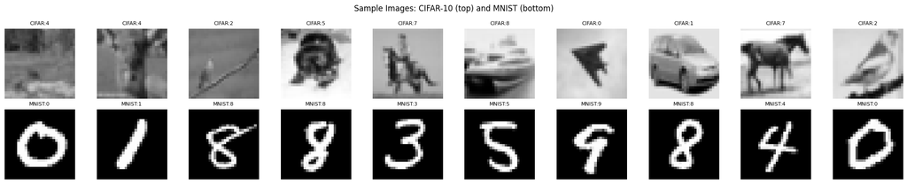

```python
# Visualize some samples
fig, axes = plt.subplots(2, 10, figsize=(20, 4))
for i in range(10):
    axes[0, i].imshow(cifar_X_train[i], cmap='gray', vmin=50, vmax=200)
    axes[0, i].set_title(f'CIFAR:{cifar_y_train[i]}', fontsize=8)
    axes[0, i].axis('off')
    axes[1, i].imshow(mnist_X_train[i], cmap='gray', vmin=50, vmax=200)
    axes[1, i].set_title(f'MNIST:{mnist_y_train[i]}', fontsize=8)
    axes[1, i].axis('off')
plt.suptitle('Sample Images: CIFAR-10 (top) and MNIST (bottom)')
plt.tight_layout()
plt.show()
```

```python
# Flatten images for PCA / linear methods
def flatten_images(X):
    return X.reshape(X.shape[0], -1)

cifar_X_train_flat = flatten_images(cifar_X_train)
cifar_X_val_flat = flatten_images(cifar_X_val)
cifar_X_test_flat = flatten_images(cifar_X_test)

mnist_X_train_flat = flatten_images(mnist_X_train)
mnist_X_val_flat = flatten_images(mnist_X_val)
mnist_X_test_flat = flatten_images(mnist_X_test)

print(f"CIFAR-10 flattened: Train={cifar_X_train_flat.shape}, Test={cifar_X_test_flat.shape}")
print(f"MNIST flattened: Train={mnist_X_train_flat.shape}, Test={mnist_X_test_flat.shape}")
```

```
CIFAR-10 flattened: Train=(42000, 784), Test=(6000, 784)
MNIST flattened: Train=(49000, 784), Test=(7000, 784)
```

## Task 1: Standard PCA and Randomized PCA

- Perform standard PCA with 70% training data, identify top 30 principal components
- Train logistic regression classifier on PCA features for 10-class classification
- Draw ROC curves for test datasets
- Repeat with Randomized PCA and compare
- Calculate average SNR (dB) of reconstructed test images

```python
# Helper: Compute SNR in dB
def compute_snr_db(original, reconstructed):
    """Compute average SNR in dB between original and reconstructed images."""
    signal_power = np.mean(original ** 2, axis=1)
    noise = original - reconstructed
    noise_power = np.mean(noise ** 2, axis=1)
    # Avoid division by zero
    noise_power = np.maximum(noise_power, 1e-10)
    snr = 10 * np.log10(signal_power / noise_power)
    return np.mean(snr)

# Helper: Plot ROC curves for 10-class classification
def plot_roc_curve(y_true, y_score, n_classes, title):
    """Plot ROC curve for multi-class classification."""
    # Binarize labels
    y_true_bin = label_binarize(y_true, classes=list(range(n_classes)))

    fpr = dict()
    tpr = dict()
    roc_auc = dict()

    for i in range(n_classes):
        fpr[i], tpr[i], _ = roc_curve(y_true_bin[:, i], y_score[:, i])
        roc_auc[i] = auc(fpr[i], tpr[i])

    # Micro-average
    fpr['micro'], tpr['micro'], _ = roc_curve(y_true_bin.ravel(), y_score.ravel())
    roc_auc['micro'] = auc(fpr['micro'], tpr['micro'])

    plt.figure(figsize=(10, 8))
    colors = plt.cm.tab10(np.linspace(0, 1, n_classes))

    for i, color in zip(range(n_classes), colors):
        plt.plot(fpr[i], tpr[i], color=color, lw=1.5,
                 label=f'Class {i} (AUC = {roc_auc[i]:.3f})')

    plt.plot(fpr['micro'], tpr['micro'], color='deeppink', lw=2, linestyle=':',
             label=f'Micro-avg (AUC = {roc_auc["micro"]:.3f})')

    plt.plot([0, 1], [0, 1], 'k--', lw=1)
    plt.xlim([0.0, 1.0])
    plt.ylim([0.0, 1.05])
    plt.xlabel('False Positive Rate', fontsize=12)
    plt.ylabel('True Positive Rate', fontsize=12)
    plt.title(title, fontsize=14)
    plt.legend(loc='best', fontsize=8)
    plt.tight_layout()
    plt.show()

    return roc_auc
```

```
============================================================
Standard PCA on CIFAR-10
============================================================
Top 30 eigenvalues: [304233.65831215 122895.70289793  73606.3646071   41450.94117163
  31175.34071617  29751.72574579  23982.24737747  22466.74736427
  16004.23971007  14238.07827072  11745.78458062  11416.43466065
  10815.14588347  10055.66094656   8912.99849091   7543.19024444
   7030.14975983   6408.56028629   6395.05909873   5347.09815996
   5316.63244369   4953.03207592   4812.66363773   4733.7213179
   4317.97519222   4269.48975694   3758.01012308   3597.50427835
   3448.91276098   3306.89360821]
Total variance explained by 30 components: 84.96%
Average SNR (Standard PCA, CIFAR-10): 20.04 dB
Logistic Regression Accuracy (Standard PCA, CIFAR-10): 29.50%
```

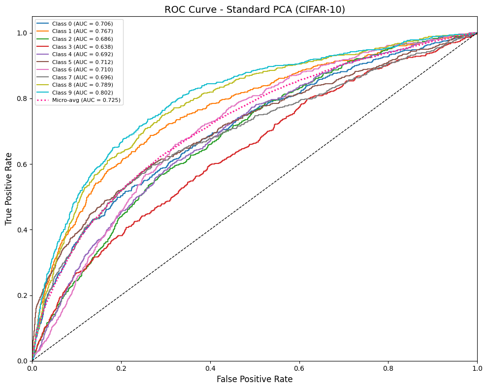

```python
# ===== Standard PCA on CIFAR-10 =====
print("="*60)
print("Standard PCA on CIFAR-10")
print("="*60)

pca_cifar = PCA(n_components=30, svd_solver='full')
cifar_X_train_pca = pca_cifar.fit_transform(cifar_X_train_flat)
cifar_X_test_pca = pca_cifar.transform(cifar_X_test_flat)

print(f"Top 30 eigenvalues: {pca_cifar.explained_variance_[:30]}")
print(f"Total variance explained by 30 components: {pca_cifar.explained_variance_ratio_.sum()*100:.2f}%")

# Reconstruct and compute SNR
cifar_X_test_recon_pca = pca_cifar.inverse_transform(cifar_X_test_pca)
snr_cifar_pca = compute_snr_db(cifar_X_test_flat, cifar_X_test_recon_pca)
print(f"Average SNR (Standard PCA, CIFAR-10): {snr_cifar_pca:.2f} dB")

# Logistic Regression on PCA features
lr_cifar_pca = LogisticRegression(max_iter=1000, multi_class='ovr', random_state=42)
lr_cifar_pca.fit(cifar_X_train_pca, cifar_y_train)
cifar_pca_score = lr_cifar_pca.score(cifar_X_test_pca, cifar_y_test)
print(f"Logistic Regression Accuracy (Standard PCA, CIFAR-10): {cifar_pca_score*100:.2f}%")

# ROC Curve
cifar_y_score_pca = lr_cifar_pca.predict_proba(cifar_X_test_pca)
roc_auc_cifar_pca = plot_roc_curve(cifar_y_test, cifar_y_score_pca, 10,
                                     'ROC Curve - Standard PCA (CIFAR-10)')
```

```
============================================================
Standard PCA on MNIST
============================================================
Top 30 eigenvalues: [115691.33    84670.68    72935.56    64402.38    58067.883   51242.203
  38845.05    34338.48    32735.803   27981.727   25014.268   24219.674
  20379.428   20170.152   18825.17    17696.193   15603.994   15180.693
  14119.309   13688.121   12700.558   11975.674   11383.3955  10862.941
  10540.834    9970.653    9636.101    9330.289    8795.31     8202.73  ]
Total variance explained by 30 components: 73.18%
Average SNR (Standard PCA, MNIST): 12.58 dB
Logistic Regression Accuracy (Standard PCA, MNIST): 87.80%
```

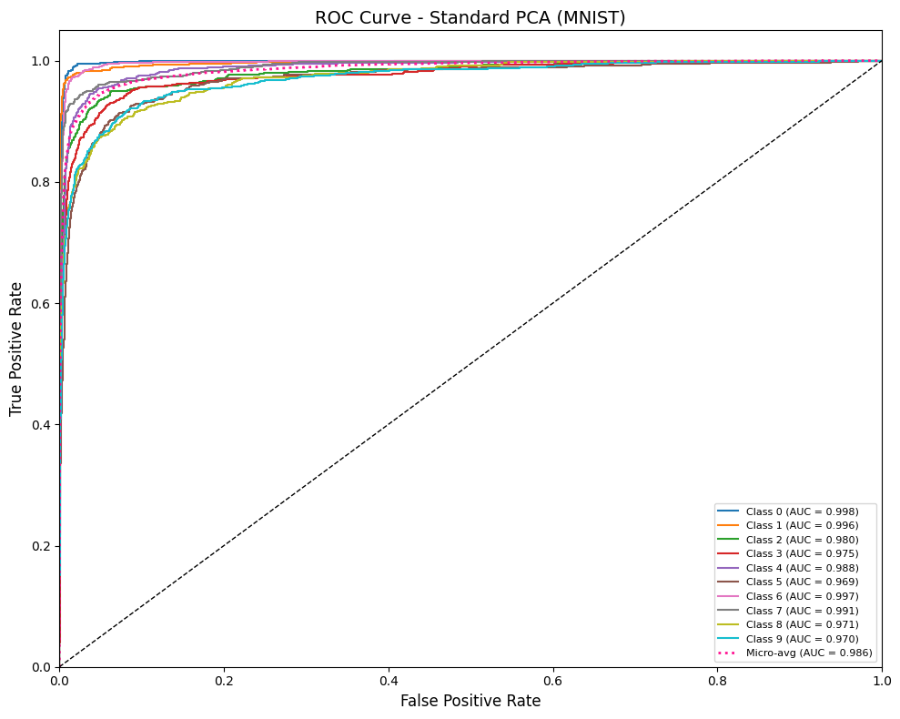

```python
# ===== Standard PCA on MNIST =====
print("="*60)
print("Standard PCA on MNIST")
print("="*60)

pca_mnist = PCA(n_components=30, svd_solver='full')
mnist_X_train_pca = pca_mnist.fit_transform(mnist_X_train_flat)
mnist_X_test_pca = pca_mnist.transform(mnist_X_test_flat)

print(f"Top 30 eigenvalues: {pca_mnist.explained_variance_[:30]}")
print(f"Total variance explained by 30 components: {pca_mnist.explained_variance_ratio_.sum()*100:.2f}%")

# Reconstruct and compute SNR
mnist_X_test_recon_pca = pca_mnist.inverse_transform(mnist_X_test_pca)
snr_mnist_pca = compute_snr_db(mnist_X_test_flat, mnist_X_test_recon_pca)
print(f"Average SNR (Standard PCA, MNIST): {snr_mnist_pca:.2f} dB")

# Logistic Regression on PCA features
lr_mnist_pca = LogisticRegression(max_iter=1000, multi_class='ovr', random_state=42)
lr_mnist_pca.fit(mnist_X_train_pca, mnist_y_train)
mnist_pca_score = lr_mnist_pca.score(mnist_X_test_pca, mnist_y_test)
print(f"Logistic Regression Accuracy (Standard PCA, MNIST): {mnist_pca_score*100:.2f}%")

# ROC Curve
mnist_y_score_pca = lr_mnist_pca.predict_proba(mnist_X_test_pca)
roc_auc_mnist_pca = plot_roc_curve(mnist_y_test, mnist_y_score_pca, 10,
                                     'ROC Curve - Standard PCA (MNIST)')
```

```
============================================================
Randomized PCA on CIFAR-10
============================================================
Top 30 eigenvalues: [304233.65831215 122895.70289793  73606.3646071   41450.94117163
  31175.34071617  29751.72574579  23982.24737747  22466.74736427
  16004.23971007  14238.07827068  11745.78457954  11416.43466025
  10815.1458818   10055.66094481   8912.99848465   7543.1901262
   7030.14916289   6408.55873233   6395.05880973   5347.09511621
   5316.62380122   4953.00668902   4812.64296463   4733.70518426
   4317.89818842   4269.1799767    3757.50209572   3596.46530471
   3448.35777727   3300.97717647]
Total variance explained by 30 components: 84.96%
Average SNR (Randomized PCA, CIFAR-10): 20.04 dB
Logistic Regression Accuracy (Randomized PCA, CIFAR-10): 29.48%
```

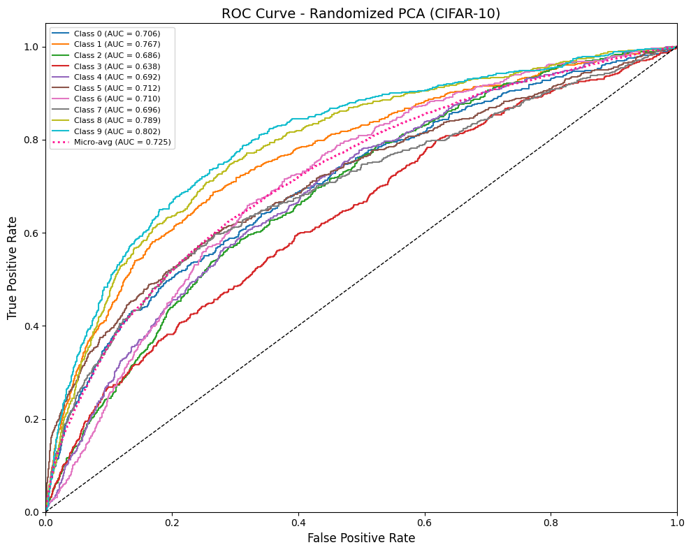

```python
# ===== Randomized PCA on CIFAR-10 =====
print("="*60)
print("Randomized PCA on CIFAR-10")
print("="*60)

rpca_cifar = PCA(n_components=30, svd_solver='randomized', random_state=42)
cifar_X_train_rpca = rpca_cifar.fit_transform(cifar_X_train_flat)
cifar_X_test_rpca = rpca_cifar.transform(cifar_X_test_flat)

print(f"Top 30 eigenvalues: {rpca_cifar.explained_variance_[:30]}")
print(f"Total variance explained by 30 components: {rpca_cifar.explained_variance_ratio_.sum()*100:.2f}%")

# Reconstruct and compute SNR
cifar_X_test_recon_rpca = rpca_cifar.inverse_transform(cifar_X_test_rpca)
snr_cifar_rpca = compute_snr_db(cifar_X_test_flat, cifar_X_test_recon_rpca)
print(f"Average SNR (Randomized PCA, CIFAR-10): {snr_cifar_rpca:.2f} dB")

# Logistic Regression on Randomized PCA features
lr_cifar_rpca = LogisticRegression(max_iter=1000, multi_class='ovr', random_state=42)
lr_cifar_rpca.fit(cifar_X_train_rpca, cifar_y_train)
cifar_rpca_score = lr_cifar_rpca.score(cifar_X_test_rpca, cifar_y_test)
print(f"Logistic Regression Accuracy (Randomized PCA, CIFAR-10): {cifar_rpca_score*100:.2f}%")

# ROC Curve
cifar_y_score_rpca = lr_cifar_rpca.predict_proba(cifar_X_test_rpca)
roc_auc_cifar_rpca = plot_roc_curve(cifar_y_test, cifar_y_score_rpca, 10,
                                      'ROC Curve - Randomized PCA (CIFAR-10)')
```

```
============================================================
Randomized PCA on MNIST
============================================================
Top 30 eigenvalues: [115691.3    84670.51   72935.664  64402.387  58067.863  51242.188
  38845.035  34338.508  32735.783  27981.719  25014.262  24219.68
  20379.41   20170.143  18825.182  17696.17   15603.995  15180.716
  14119.285  13688.111  12700.539  11975.645  11383.277  10862.73
  10540.649   9969.959   9635.517   9329.43    8794.323   8199.785]
Total variance explained by 30 components: 73.17%
Average SNR (Randomized PCA, MNIST): 12.58 dB
Logistic Regression Accuracy (Randomized PCA, MNIST): 87.77%
```

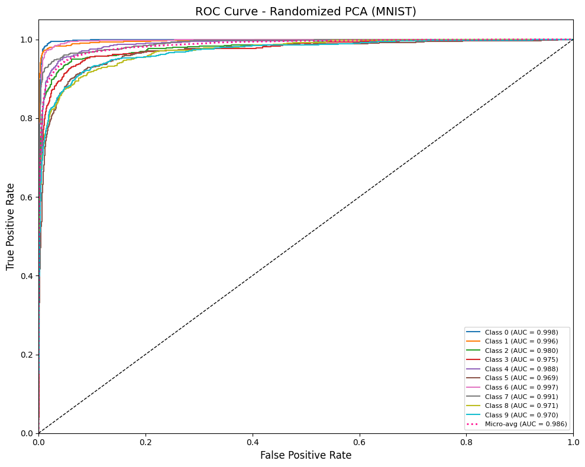

```python
# ===== Randomized PCA on MNIST =====
print("="*60)
print("Randomized PCA on MNIST")
print("="*60)

rpca_mnist = PCA(n_components=30, svd_solver='randomized', random_state=42)
mnist_X_train_rpca = rpca_mnist.fit_transform(mnist_X_train_flat)
mnist_X_test_rpca = rpca_mnist.transform(mnist_X_test_flat)

print(f"Top 30 eigenvalues: {rpca_mnist.explained_variance_[:30]}")
print(f"Total variance explained by 30 components: {rpca_mnist.explained_variance_ratio_.sum()*100:.2f}%")

# Reconstruct and compute SNR
mnist_X_test_recon_rpca = rpca_mnist.inverse_transform(mnist_X_test_rpca)
snr_mnist_rpca = compute_snr_db(mnist_X_test_flat, mnist_X_test_recon_rpca)
print(f"Average SNR (Randomized PCA, MNIST): {snr_mnist_rpca:.2f} dB")

# Logistic Regression on Randomized PCA features
lr_mnist_rpca = LogisticRegression(max_iter=1000, multi_class='ovr', random_state=42)
lr_mnist_rpca.fit(mnist_X_train_rpca, mnist_y_train)
mnist_rpca_score = lr_mnist_rpca.score(mnist_X_test_rpca, mnist_y_test)
print(f"Logistic Regression Accuracy (Randomized PCA, MNIST): {mnist_rpca_score*100:.2f}%")

# ROC Curve
mnist_y_score_rpca = lr_mnist_rpca.predict_proba(mnist_X_test_rpca)
roc_auc_mnist_rpca = plot_roc_curve(mnist_y_test, mnist_y_score_rpca, 10,
                                      'ROC Curve - Randomized PCA (MNIST)')
```

```python
# ===== Comparison Table: Standard PCA vs Randomized PCA =====
print("\n" + "="*70)
print("COMPARISON: Standard PCA vs Randomized PCA")
print("="*70)
print(f"{'Metric':<35} {'Std PCA':>15} {'Rand PCA':>15}")
print("-" * 65)
print(f"{'CIFAR-10 Accuracy (%)':<35} {cifar_pca_score*100:>15.2f} {cifar_rpca_score*100:>15.2f}")
print(f"{'CIFAR-10 SNR (dB)':<35} {snr_cifar_pca:>15.2f} {snr_cifar_rpca:>15.2f}")
print(f"{'CIFAR-10 Variance Explained (%)':<35} {pca_cifar.explained_variance_ratio_.sum()*100:>15.2f} {rpca_cifar.explained_variance_ratio_.sum()*100:>15.2f}")
print(f"{'MNIST Accuracy (%)':<35} {mnist_pca_score*100:>15.2f} {mnist_rpca_score*100:>15.2f}")
print(f"{'MNIST SNR (dB)':<35} {snr_mnist_pca:>15.2f} {snr_mnist_rpca:>15.2f}")
print(f"{'MNIST Variance Explained (%)':<35} {pca_mnist.explained_variance_ratio_.sum()*100:>15.2f} {rpca_mnist.explained_variance_ratio_.sum()*100:>15.2f}")

print("\nObservation: Standard PCA and Randomized PCA produce nearly identical")
print("results, with Randomized PCA being computationally faster for large datasets.")
```

```
======================================================================
COMPARISON: Standard PCA vs Randomized PCA
======================================================================
Metric                                      Std PCA        Rand PCA
-----------------------------------------------------------------
CIFAR-10 Accuracy (%)                         29.50           29.48
CIFAR-10 SNR (dB)                             20.04           20.04
CIFAR-10 Variance Explained (%)               84.96           84.96
MNIST Accuracy (%)                            87.80           87.77
MNIST SNR (dB)                                12.58           12.58
MNIST Variance Explained (%)                  73.18           73.17

Observation: Standard PCA and Randomized PCA produce nearly identical
results, with Randomized PCA being computationally faster for large datasets.
```